# How to analyze Whatsapp conversation using Pandas and Matplotlib

[figure not shown]

```python
#convert datetime
from datetime import date
from datetime import datetime
#data processing/manipulation/record
import pandas as pd
#plotting results
import matplotlib.pyplot as plt
#propreties
import numpy as np
```

## 1. Read raw file from Whatsapp

```python
file = open("Michi.txt",'r+',encoding="utf-8")
text = file.read()
file.close()
text[:500]
```

```
"02/03/19, 22:44 - I messaggi inviati a questa chat e le chiamate sono ora protetti con la crittografia end-to-end. Tocca per maggiori info.\n02/03/19, 22:44 - Matteo 🐢: http://www.ansa.it/lombardia/notizie/2018/12/17/qualita-della-vita-milano-al-top_18096968-6cfe-448b-9af0-c66e1cc4e920.html\n02/03/…
```

## 2. Extract text grouping in elements

The text is downloaded as a plain txt, so we need to do some manipulation in order to clean it. The messages are stored as: day , hour - author: text, \n so in order to have all the messages, we need first to extract the single messages from the plain text, then all the single elements in it.

```python
tot = []
errors = []
#'\n' is end of line
for i in text.split("\n")[1:]:
    #data format: day , hour - author: text
    try:
    #save the elements in an array
        giorno = i.split(",")[0].strip()
        ora = i.split(",")[1].split("-")[0].strip()
        autore = i.split("-")[1].split(":")[0].strip()
        messaggio = i.split(": ")[1]
        tot.append([giorno,ora,autore,messaggio])
    #exception raised if split() function can't be used
    except:
        errors.append(i)
print("%Messaggi persi:", round((len(errors)/len(text.split("\n")))*100,2))
```

```
%Messaggi persi: 0.34
```

```python
print("Numero errori:",len(errors),end="\n")
print("Esempi messaggi non salvati correttamente:\n",errors[:10])
```

```
Numero errori: 95
Esempi messaggi non salvati correttamente:
 ['Tu cosa fai?', "Meglio se sto qua l'anno prossimo😂", "vorrei anch'io... 💪🏼", "ma c'è così tanto da sapere?", 'Io: https://youtu.be/fR17cJzjAUg', 'Chiaramente si chiaramente no ', 'Forse', 'Vita sociale level pensione', '👴🏻', '😎']
```

## 3. Pandas gymnastic and dataset creation

To enrich the dataset, we decided to extract other elements that might be useful, such the total number of character in each text, the conversion of the date in a specific type that please Python, such as datetime.

```python
#lets create a pandas dataframe
chat = pd.DataFrame(tot,columns=["Giorno","Ora","Autore","Messaggio"])

#function for counting the character
def contacaratteri(string):
    return len(string)

#function for convert data with minutes and hour
def convertiData(string,string1):
    giorno,mese,anno = string.split("/")[0],string.split("/")[1],2019
    ore,minuti = string1.split(":")[0],string1.split(":")[1]
    return datetime(int(anno), int(mese), int(giorno),int(ore),int(minuti))

#function for convert data without minutes and hour
def convertiGiorno(string):
    giorno,mese,anno = string.split("/")[0],string.split("/")[1],2019
    return datetime(int(anno), int(mese), int(giorno),0,0)

#function for convert data without minutes,hour and days
def convertiMese(string):
    mese,anno = string.split("/")[1],2019
    return datetime(int(anno), int(mese), 1,0,0)

#enrich the dataset with new columns with useful information using the above functions
dt = datetime.combine(date.today(), datetime.min.time())
chat["Caratteri"] = chat.apply(lambda row:contacaratteri(row["Messaggio"]),axis=1)
chat["Datetime"] = chat.apply(lambda row:convertiData(row["Giorno"],row["Ora"]),axis=1)
chat["Giorni"] = chat.apply(lambda row:convertiGiorno(row["Giorno"]),axis=1)
chat["Mese"] = chat.apply(lambda row:convertiMese(row["Giorno"]),axis=1)
#save the dataset
chat.to_csv("MichivsMaz.csv")
```

```python
#load the dataset for future uses
chat = pd.read_csv("MichivsMaz.csv")
```

## 5. Temporal analysis using Matplotlib

Using the datetime we can plot the distribution of text messages on a certain period of time

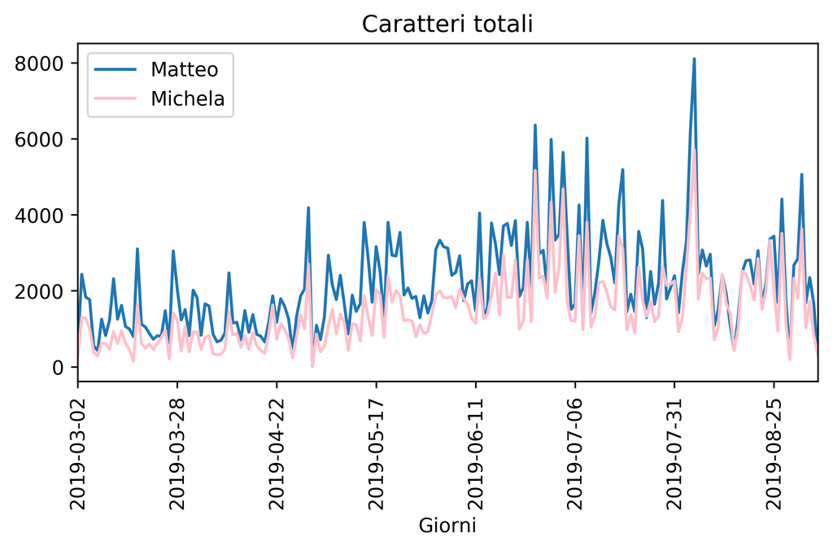

```python
#create a plot with number of words used each day
plt.figure(dpi=420)
plt.title("Caratteri totali")

#group character used each day
chat.loc[chat["Autore"]=="Matteo 🐢"].groupby("Giorni")["Caratteri"].sum().plot()
chat.loc[chat["Autore"]=="Michela🌻"].groupby("Giorni")["Caratteri"].sum().plot(color="pink")
plt.legend(["Matteo","Michela"])
plt.xticks(rotation=90)

#save the figure (thight_layout() is used for graphics only)
plt.tight_layout()
plt.savefig("Report_Caratteri.png")
plt.show()
```

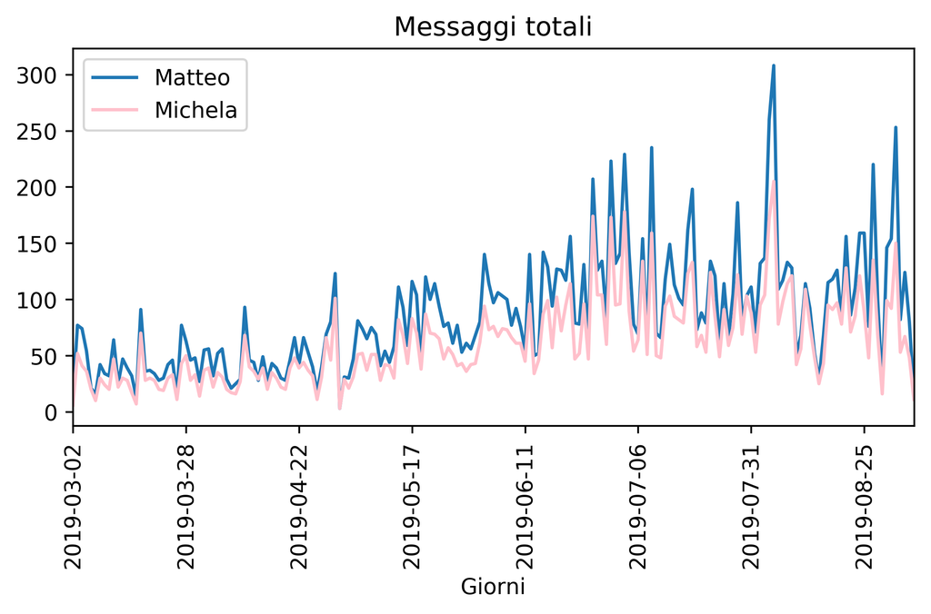

```python
#create a plot showing the number of messages each day
fig, ax = plt.subplots(dpi=420)
plt.title("Messaggi totali")

#group number of messages send each day
chat.loc[chat["Autore"]=="Matteo 🐢"].groupby("Giorni")["Messaggio"].count().plot()
chat.loc[chat["Autore"]=="Michela🌻"].groupby("Giorni")["Messaggio"].count().plot(color="pink")
plt.legend(["Matteo","Michela"])
plt.xticks(rotation=90)

#save the results
plt.tight_layout()
plt.savefig("Report_Messaggi.png")
plt.show()
```

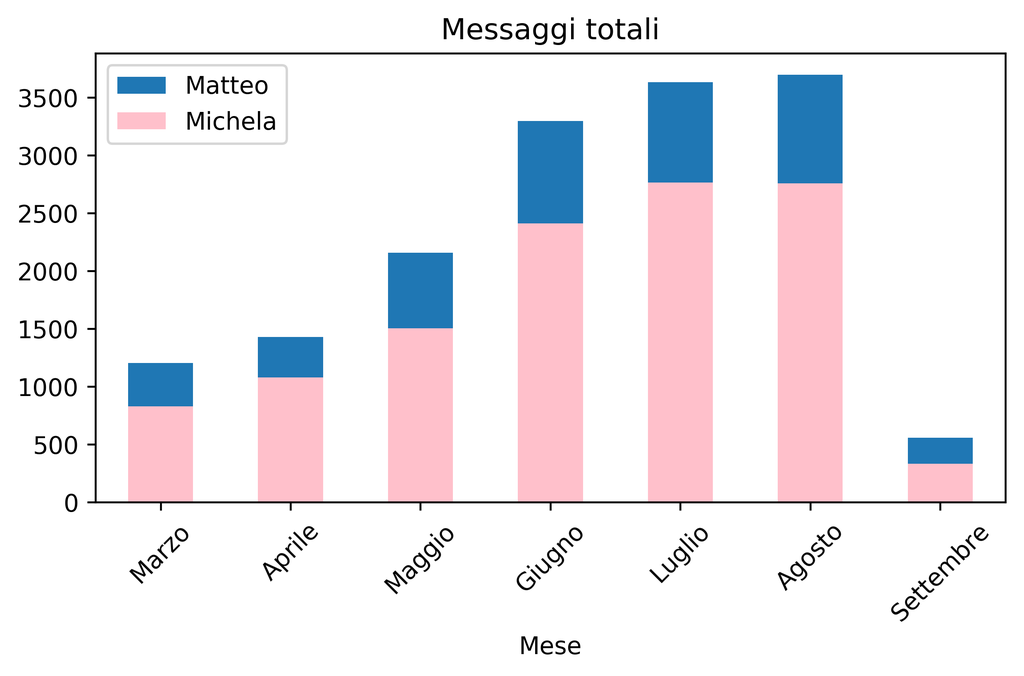

```python
#create a plot showing the number of messages each day
fig, ax = plt.subplots(dpi=420)
plt.title("Messaggi totali")

#group number of messages send in a month
chat.loc[chat["Autore"]=="Matteo 🐢"].groupby("Mese")["Mese"].count().plot('bar')
chat.loc[chat["Autore"]=="Michela🌻"].groupby("Mese")["Mese"].count().plot('bar',color="pink")
plt.legend(["Matteo","Michela"])
mesi = ["Marzo","Aprile","Maggio","Giugno","Luglio","Agosto","Settembre"]
plt.xticks(range(len(mesi)),mesi,rotation=45)

#save the results
plt.tight_layout()
plt.savefig("Report_Mensile.png")
plt.show()
```

## 6. Lexical Analysis using Matplotlib

Discover most used words

```python
#most used words by an author
from collections import Counter
words = []
for i in chat.loc[chat["Autore"]=="Matteo 🐢"]["Messaggio"]:
    for j in i.split(" "):
        words.append(str.lower(j))
print(Counter(words).most_common()[:10],"\n")

#lexical richness: higher is the value, more words are used
def lexical_richness(text):
    return (len(set(text))/len(text))
print("Ricchezza lessicale:", lexical_richness(words))
```

```
[('che', 1966), ('non', 1621), ('ma', 1441), ('a', 1354), ('mi', 1189), ('e', 1070), ('di', 1039), ('la', 914), ('dai', 869), ('<media', 851)]

Ricchezza lessicale: 0.13505293842989285
```

[figure not shown]

```python
#plotting the most used words for author
percentages = []
def percentage(count, total):
    return 100 * (count / total)
for i in set(words):
    percentages.append([i,round(percentage(words.count(i), len(words)),3)])

df = pd.DataFrame(percentages,columns=["Name","%"])
labels = df.sort_values("%",ascending=False)[:20]["Name"]
values = df.sort_values("%",ascending=False)[:20]["%"]
plt.figure(dpi=420)
plt.title("Percentuale parole più usate da Matteo")
plt.bar(x=labels,height=values)
x = -0.5
for i in values:
    plt.annotate("{0}%".format(round(i,2)),xy=(x,i+0.05),size=5,rotation=10)
    x = x+1
plt.xticks(rotation=45)
plt.show()
```

```python
from collections import Counter
words = []
for i in chat.loc[chat["Autore"]=="Michela🌻"]["Messaggio"]:
    for j in i.split(" "):
        words.append(str.lower(j))
print(Counter(words).most_common()[:10],"\n")

def lexical_richness(text):
    return (len(set(text))/len(text))
print("Ricchezza lessicale:", lexical_richness(words))
```

```
[('ma', 1780), ('che', 1479), ('non', 1416), ('a', 934), ('si', 793), ('mi', 709), ('la', 643), ('e', 614), ('di', 610), ('no', 564)]

Ricchezza lessicale: 0.13060810187321215
```

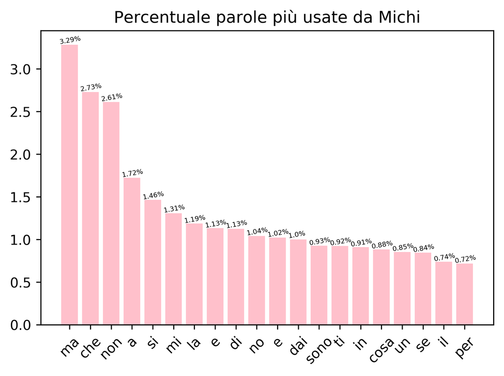

```python
percentages = []
for i in set(words):
    percentages.append([i,round(percentage(words.count(i), len(words)),3)])
df = pd.DataFrame(percentages,columns=["Name","%"])
labels = df.sort_values("%",ascending=False)[:20]["Name"]
values = df.sort_values("%",ascending=False)[:20]["%"]
plt.figure(dpi=420)
plt.title("Percentuale parole più usate da Michi")
plt.bar(x=labels,height=values,color="pink")
x = -0.5
for i in values:
    plt.annotate("{0}%".format(round(i,2)),xy=(x,i+0.05),size=5,rotation=10)
    x = x+1
plt.xticks(rotation=45)
plt.show()
```

```python
#most used phrases from author
from collections import Counter
phrase = []
for i in chat.loc[chat["Autore"]=="Matteo 🐢"]["Messaggio"]:
    phrase.append(str.lower(i))
Counter(phrase).most_common()

#higher the results, different phrases are used
print("Ricchezza lessicale:", lexical_richness(phrase))
```

```
Ricchezza lessicale: 0.8291674497274948
```

```python
#most used phrases from author
from collections import Counter
phrase = []
for i in chat.loc[chat["Autore"]=="Michela🌻"]["Messaggio"]:
    phrase.append(str.lower(i))
Counter(phrase).most_common()

#higher the results, different phrases are used
print("Ricchezza lessicale:", lexical_richness(phrase))
```

```
Ricchezza lessicale: 0.7496141313668324
```

```python
# who's the last one that went to bed? Looking for 'goodnight' or abbreviation
def buonanotte(string):
    if 'buonanotte' in string.lower():
        return True
    elif 'notte' in string.lower():
        return True
    else:
        return False
chat["Buonanotte"] = chat.apply(lambda row:buonanotte(row["Messaggio"]),axis=1)
```

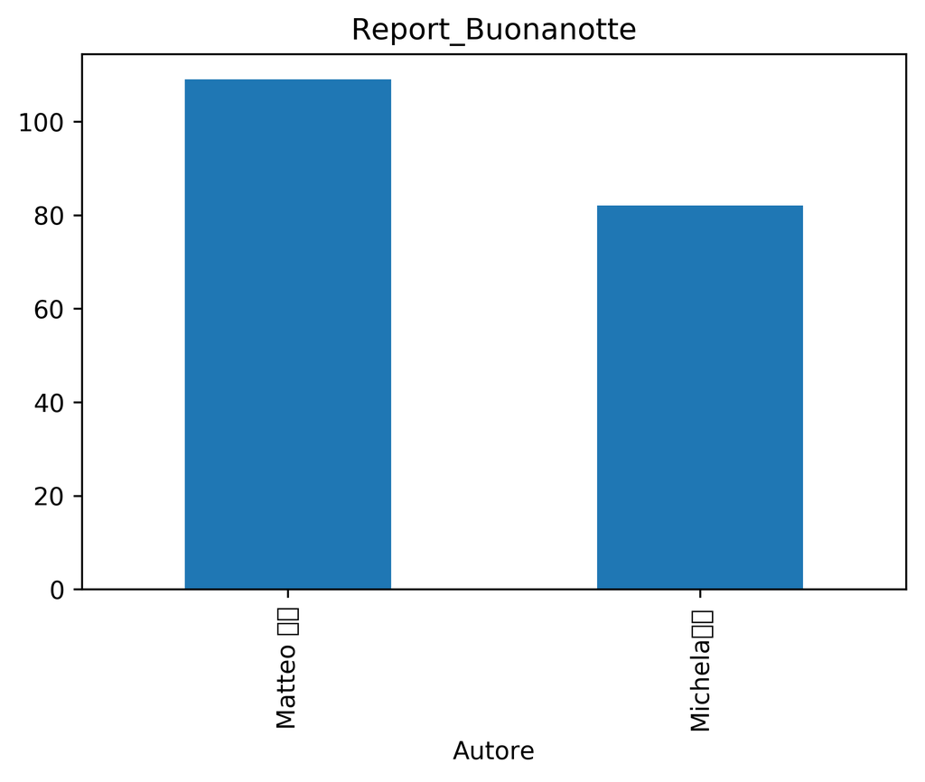

```python
#who's the one that sent the most goodnights?
plt.figure(dpi = 420)
plt.title("Report_Buonanotte")
chat.loc[chat["Buonanotte"]==True].groupby("Autore")["Buonanotte"].count().plot("bar")
plt.show()
```

```python
sets = []
sets_1 = []
def set_hour(string):
    return datetime(2019,1,1,int(string.split(":")[0]),int(string.split(":")[1]))
for i in chat.loc[chat["Buonanotte"]==True].loc[chat["Autore"]=="Matteo 🐢"]["Ora"]:
    sets_1.append(set_hour(i))
for i in chat.loc[chat["Buonanotte"]==True].loc[chat["Autore"]=="Michela🌻"]["Ora"]:
    sets.append(set_hour(i))
```

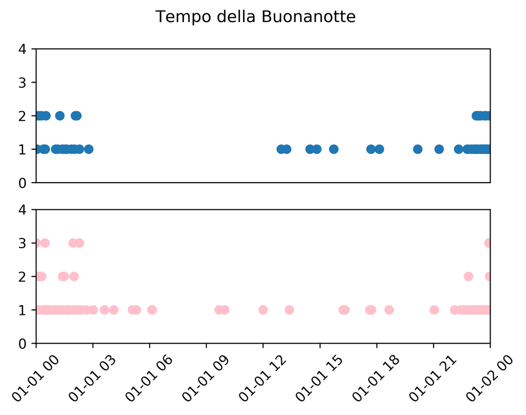

```python
plt.figure(dpi=420)
plt.suptitle("Tempo della Buonanotte")
plt.subplot(211)
labels, values = zip(*Counter(sets).items())
plt.scatter(labels, values)
plt.xticks(rotation=45)
plt.xlim(
    left=datetime(2019,1,1,0,0,), # the one that doesn't change
    right=datetime(2019,1,2,0,0,) # the latest datetime in your dataset
)
plt.xticks([])
plt.ylim([0,4])
plt.subplot(212)
labels, values = zip(*Counter(sets_1).items())
plt.scatter(labels, values,color="pink")
plt.xticks(rotation=45)
plt.xlim(
    left=datetime(2019,1,1,0,0,), # the one that doesn't change
    right=datetime(2019,1,2,0,0,) # the latest datetime in your dataset
)
plt.ylim([0,4])
plt.show()
```

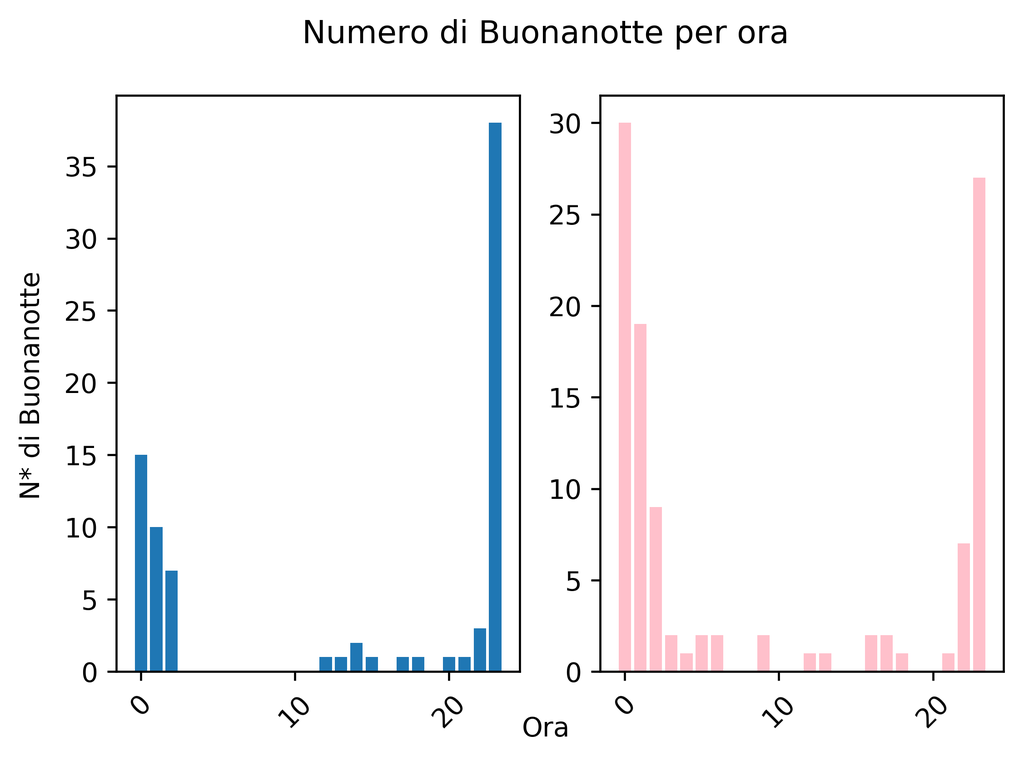

```python
fig,ax = plt.subplots(1,2,sharex=True,sharey=True,dpi=420)
plt.suptitle("Numero di Buonanotte per ora")
fig.text(0.5, 0.04, 'Ora', ha='center')
fig.text(0.04, 0.5, 'N* di Buonanotte', va='center', rotation='vertical')
plt.subplot(1,2,1)
labels, values = zip(*Counter(h.hour for h in sets).items())
plt.bar(labels, values)
plt.xticks(rotation=45)
plt.subplot(1,2,2)
labels, values = zip(*Counter(h.hour for h in sets_1).items())
plt.bar(labels, values,color="pink")
plt.xticks(rotation=45)
plt.show()
```

## To sum up

When you're significant other tells you that you never text they back or you don't care of them because you're not going to send them the goodnight, try to have a data driven approach in your discussion.  
For example i show them this notebook and they went maddest, but who cares i was right  
. **¯\_(ツ)_/¯**

## Let's keep us in contact: [TWITTER](https://twitter.com/chumpblocckami)